# Biostat M280 Homework 2

### Exercise 7.5.2.1

1. How could you rescale the count dataset above to more clearly show the distribution of cut within colour, or colour within cut?  
   *To more clearly show the distribution of cut within color, I would first separate the data by color and then calculate the proportion of each cut within each color. To show the distribution of color within cut, I would group the data by cut and then calculate the proportions of each color within each cut. Using proportions rather than counts helps with comparison because then each value is scaled proportionally.*

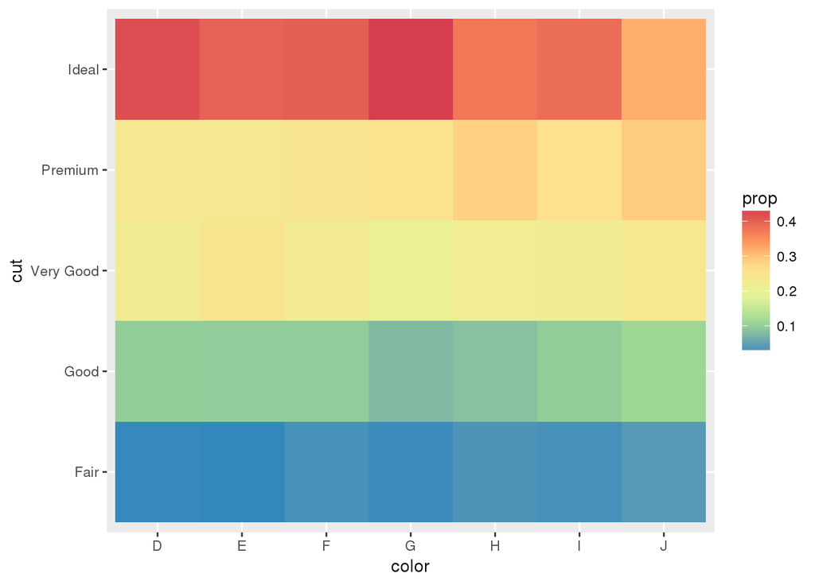

   ```r
   diamonds %>%
     count(color, cut) %>%
     group_by(color) %>%
     mutate(prop = n / sum(n)) %>%
     ggplot(aes(x = color, y = cut, fill = prop)) +
       geom_tile() +
       scale_fill_distiller(palette = "Spectral")
   ```

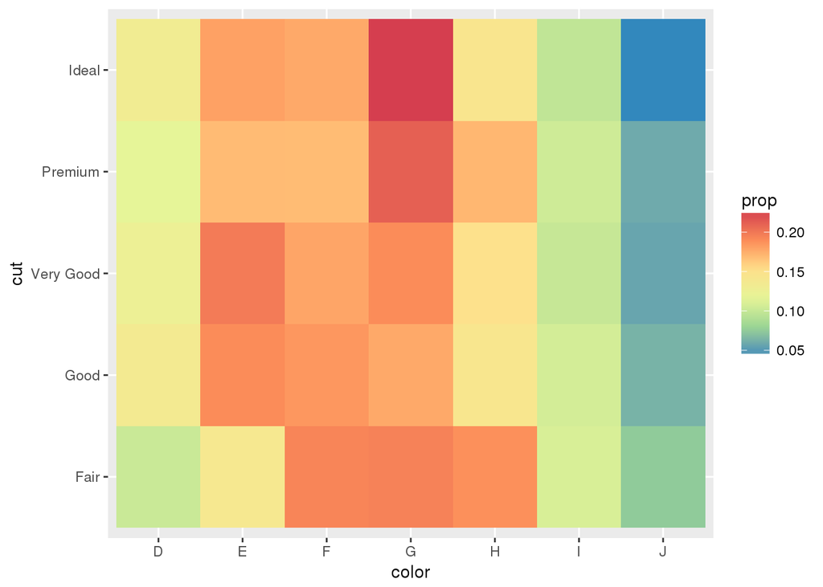

   ```r
   diamonds %>%
     count(color, cut) %>%
     group_by(cut) %>%
     mutate(prop = n / sum(n)) %>%
     ggplot(aes(x = color, y = cut, fill = prop)) +
       geom_tile() +
       scale_fill_distiller(palette = "Spectral")
   ```

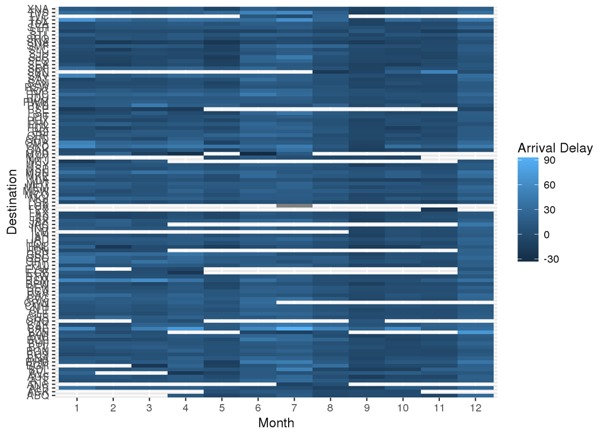

   ```r
   # initial plot
   flights %>%
     group_by(month, dest) %>%
     summarise(delay = mean(arr_delay, na.rm = TRUE)) %>%
     ggplot(aes(x = factor(month), y = dest, fill = delay)) +
       geom_tile() +
       labs(x = "Month", y = "Destination", fill = "Arrival Delay")
   ```

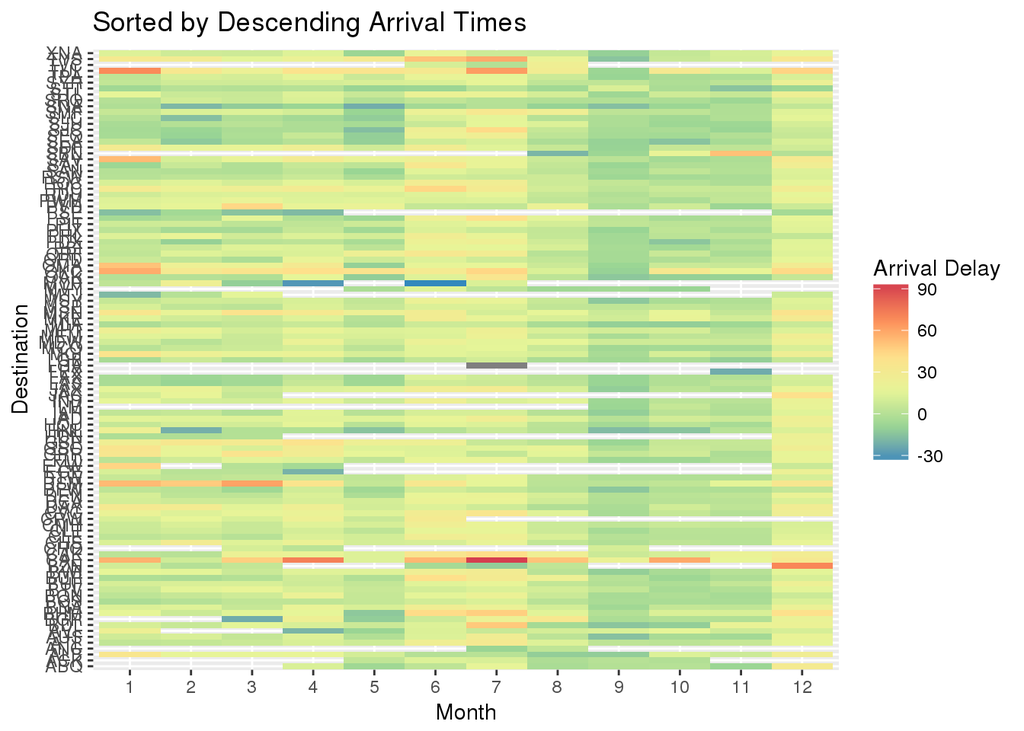

   ```r
   # improved plot
   flights %>%
     group_by(month, dest) %>%
     summarise(delay = mean(arr_delay, na.rm = TRUE)) %>%
     arrange(desc(delay)) %>%
     ggplot(aes(x = factor(month), y = dest, fill = delay)) +
       geom_tile() +
       scale_fill_distiller(palette = "Spectral") +
       labs(x = "Month", y = "Destination", fill = "Arrival Delay",
            title = "Sorted by Descending Arrival Times")
   ```

3. Why is it slightly better to use `aes(x = color, y = cut)` rather than `aes(x = cut, y = color)` in the example above?  
   *It is slightly better to have cut on the y-axis because it is an ordered categorical variable (as opposed to color). In addition, having the smaller numbers on the bottom is intuitively easier to interpret instead of having the smaller numbers on the left side.*

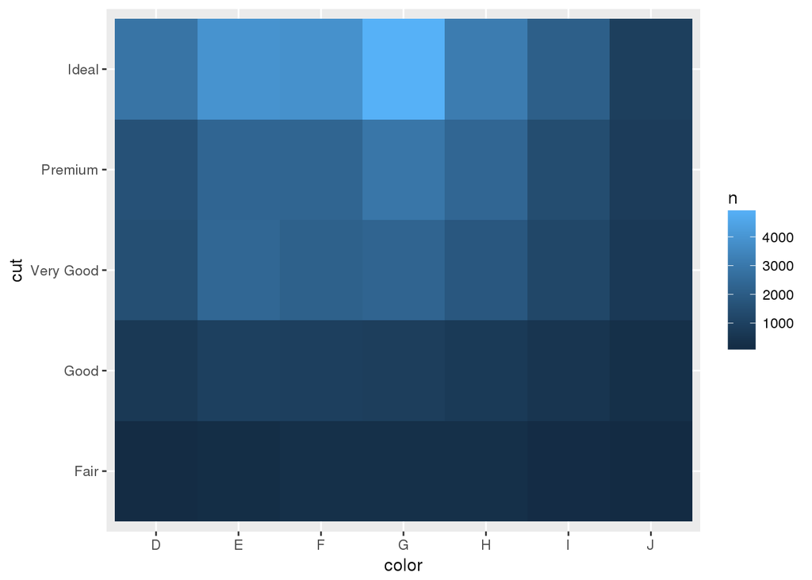

   ```r
   # example above
   diamonds %>%
     count(color, cut) %>%
     ggplot(aes(x = color, y = cut)) +
       geom_tile(aes(fill = n))
   ```

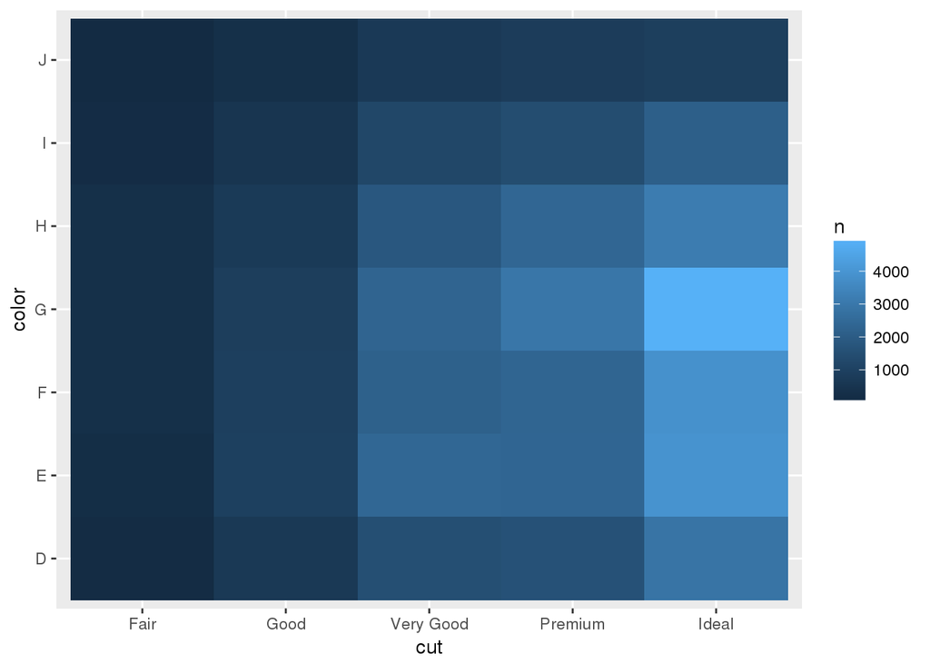

   ```r
   # using aes(x = cut, y = color)
   diamonds %>%
     count(color, cut) %>%
     ggplot(aes(x = cut, y = color)) +
       geom_tile(aes(fill = n))
   ```

### Exercise 7.5.3.1

1. Instead of summarising the conditional distribution with a boxplot, you could use a frequency polygon. What do you need to consider when using `cut_width()` vs `cut_number()`? How does that impact a visualisation of the 2d distribution of `carat` and `price`?  
   *`cut_width()` divides the x variable into bins of specified width. Since each boxplot looks the same by default, using `cut_width()` does not tell you about the number of observations in each boxplot. `cut_number()` will display the proportional amount of points within each bin. When we plot the density graph bin into consideration. Using `cut_number()`, we can see that the graph has a positive skew, indicating that most diamonds are priced in the left range (<$5000).*

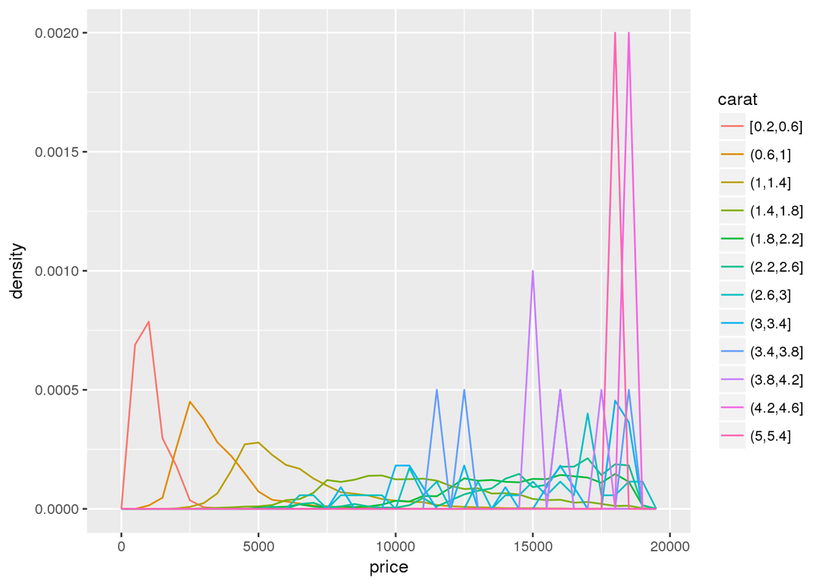

   ```r
   ggplot(diamonds, aes(x = price, y = ..density..,
                        color = cut_width(carat, 0.4))) +
     geom_freqpoly(binwidth = 500) +
     labs(color = "carat")
   ```

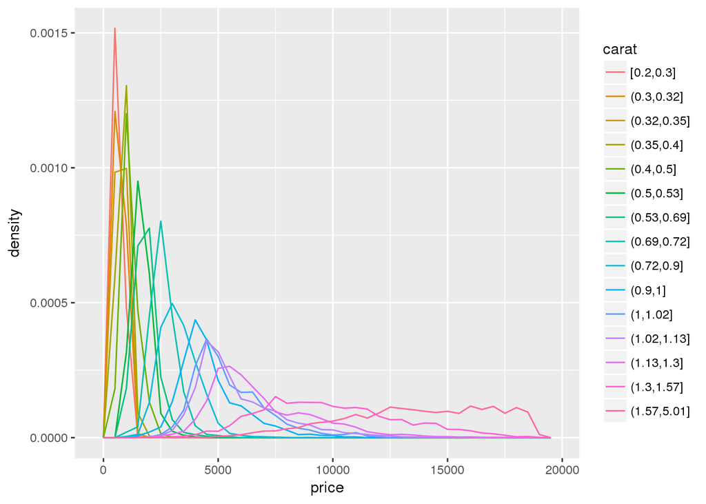

   ```r
   ggplot(diamonds, aes(x = price, y = ..density..,
                        color = cut_number(carat, 15))) +
     geom_freqpoly(binwidth = 500) +
     labs(color = "carat")
   ```

2. Visualise the distribution of carat, partitioned by price.  
   *I used horizontal boxplots to visualize the distribution of carat, partitioned by price. As the price increases, the variation in diamond carat also increases. Note: referenced from https://jrnold.github.io/r4ds-exercise-solutions/exploratory-data-analysis.html#two-continuous-variables*

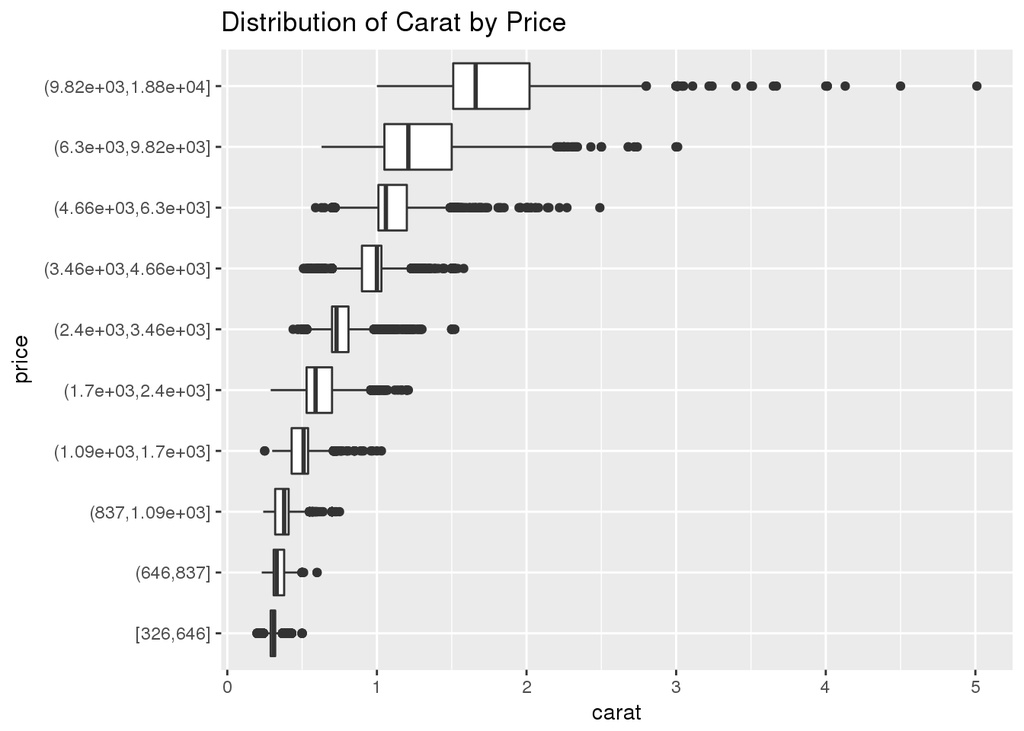

   ```r
   ggplot(diamonds) +
     geom_boxplot(aes(x = cut_number(price, 10), y = carat)) +
     labs(x = "price", title = "Distribution of Carat by Price") +
     coord_flip()
   ```

3. How does the price distribution of very large diamonds compare to small diamonds. Is it as you expect, or does it surprise you?  
   *As diamond size increases, so does the average price distribution. In addition, the price distribution of large diamonds is much more spread out than small diamonds. This result is expected, because the the other characteristics (color, clarity, cut) probably play a larger role in the price of larger carat diamonds.*
4. Combine two of the techniques you’ve learned to visualise the combined distribution of cut, carat, and price.  
   *Because cut is a categorical variable, and carat and price are continuous variables, I decided to plot carat and price, faceted by cut. I used `geom_bin2d`, which divides the coordinate plane into 2d bins. The fill color displays how many points fall into each bin.*

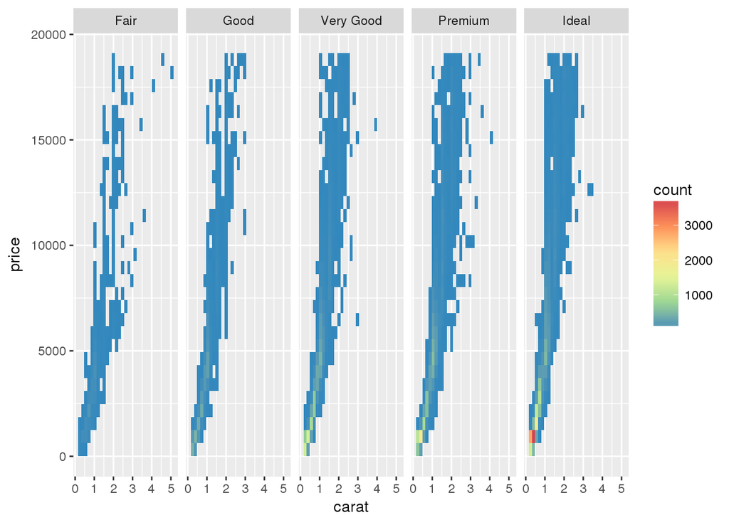

   ```r
   ggplot(diamonds) +
     geom_bin2d(aes(x = carat, y = price)) +
     scale_fill_distiller(palette = "Spectral") +
     facet_grid(. ~ cut)
   ```

5. Two dimensional plots reveal outliers that are not visible in one dimensional plots. For example, some points in the plot below have an unusual combination of x and y values, which makes the points outliers even though their x and y values appear normal when examined separately. Why is a scatterplot a better display than a binned plot for this case?  
   *A scatterplot is a better display for this case because the x and y variables have a strong correlation. When we visualized their histograms separately in Exercise 7.3.4, we saw that their distributions looked almost identical. A scatterplot of the two variables allows us to better visualize unusual combinations, which may not be apparent when examining the variables separately or when we use a binned plot.*

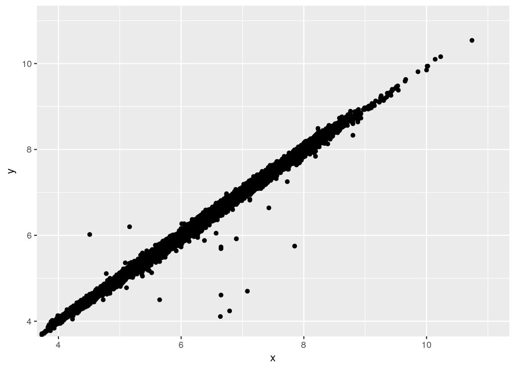

   ```r
   ggplot(data = diamonds) +
     geom_point(mapping = aes(x = x, y = y)) +
     coord_cartesian(xlim = c(4, 11), ylim = c(4, 11))
   ```

## Q2 (optional)

Read [Chapter 23](http://r4ds.had.co.nz/model-basics.html) (Model Basics) and [Chapter 24](http://r4ds.had.co.nz/model-building.html) (Model Building) of *R for Data Science* and do exercises 24.2.3 and 24.3.5.

## Q3

Redo HW1 Q2 using tidyverse.

1. How many persons are in the data set (statisticians call this `n`)? How many SNPs are in the data set (statisticians call this `p`)?

   ```r
   # import Mendel datasets into R
   setwd("/home/m280-data/hw1")
   mendel_bim <- read_tsv("/home/m280-data/hw1/merge-geno.bim",
                          col_names = c("chromosome", "SNP", "gene_dist", "BP",
                                        "allele_1", "allele_2"))
   mendel_fam <- read_delim("/home/m280-data/hw1/merge-geno.fam", delim = " ",
                            col_names = c("fam_id", "person_id", "father_id",
                                          "mother_id", "sex", "affect_stat"))
   ```

   *The number of persons in this data set is:*

   ```r
   count(mendel_fam)
   ```

   ```
   ## # A tibble: 1 x 1
   ##       n
   ##   <int>
   ## 1   959
   ```

   *The number of SNPs in this data set is:*

   ```r
   count(mendel_bim)
   ```

   ```
   ## # A tibble: 1 x 1
   ##         n
   ##     <int>
   ## 1 8348674
   ```

2. Which chromosomes does this data set contain? How many SNPs are in each chromosome?  
   *The first column lists the chromosomes that this data set contains. The second column lists the number of SNPs for each chromosome.*

   ```r
   mendel_bim %>%
     count(chromosome)
   ```

   ```
   ## # A tibble: 11 x 2
   ##    chromosome       n
   ##         <int>   <int>
   ##  1          1 1309299
   ##  2          3 1215399
   ##  3          5 1090185
   ##  4          7  980944
   ##  5          9  732013
   ##  6         11  815860
   ##  7         13  602809
   ##  8         15  491208
   ##  9         17  477990
   ## 10         19  393615
   ## 11         21  239352
   ```

3. MAP4 (microtubule-associated protein 4) is a gene on chromosome 3 spanning positions 47,892,180 bp – 48,130,769 bp. How many SNPs are located within MAP4 gene?  
   *The number of SNPs that are located within the MAP4 gene is:*

   ```r
   mendel_bim %>%
     filter(chromosome == 3 & BP >= 47892180 & BP <= 48130769) %>%
     count()
   ```

   ```
   ## # A tibble: 1 x 1
   ##       n
   ##   <int>
   ## 1   894
   ```

4. Statistical geneticists often have to reformat a data set to feed into various analysis programs. For example, to use the Mendel software http://www.genetics.ucla.edu/software/mendel, we have to reformat the data set to be read by Mendel.
   - Mendel’s SNP definition file is similar to the plink `bim` file but has format `SNP ID`, `Chromosome`, `Base Pair Position` with each field separated by a comma. Use tidyverse to convert `merge-geno.bim` to Mendel SNP definition file. The first few lines of the Mendel SNP definition file should look like
   - *I reformatted the plink `merge-geno.bim` data set to be readable by Mendel software using tidyverse, and then I piped the output to a new text file `mendel_snpdef.txt`.*

   ```r
   header <- paste("   2.40 = FILE FORMAT VERSION NUMBER.\n",
                   "8348674 = NUMBER OF SNPS LISTED HERE.", sep = "")
   mendel_snpdef <- mendel_bim %>%
     select(SNP, chromosome, BP) %>%
     unite(col = X1, sep = ",")
   write_lines(header, "mendel_snpdef.txt")
   write_delim(mendel_snpdef, "mendel_snpdef.txt", append = TRUE,
               col_names = FALSE)
   ```

   ```bash
   head -10 mendel_snpdef.txt
   ```

   ```
   ##    2.40 = FILE FORMAT VERSION NUMBER.
   ## 8348674 = NUMBER OF SNPS LISTED HERE.
   ## 1-54490,1,54490
   ## 1-55550,1,55550
   ## 1-57033,1,57033
   ## 1-57064,1,57064
   ## 1-57818,1,57818
   ## 1-58432,1,58432
   ## 1-58448,1,58448
   ## 1-58814,1,58814
   ```

   - Mendel’s pedigree file is similar to the plink `fam` file but has format  
     `Family ID`, `Person ID`, `Father ID`, `Mother ID`, `Sex` coded as M or F, `Twin Status`  
     with each field separated by a comma. Use tidyverse to convert `merge-geno.fam` to Mendel pedigree file. Since twin status is not available in plink format, we put nothing for that field. Also Mendel limits Person ID to have length less than or equal to 8 characters, so we have to strip the string `T2DG` from the IDs. First few lines of the Mendel pedigree should look like
   - *I converted the plink `merge-geno.fam` file to Mendel pedigree format using tidyverse, and then I piped the output to a text file `mendel_ped.txt`.*

   ```r
   mendel_ped <- mendel_fam %>%
     mutate(person_id = str_sub(person_id, 5, 11),
            father_id = if_else(father_id == 0, "", str_sub(father_id, 5, 11)),
            mother_id = if_else(mother_id == 0, "", str_sub(mother_id, 5, 11)),
            sex = if_else(sex == 1, "M,", "F,")) %>%
     unite(col = X1, c(fam_id, person_id, father_id, mother_id, sex),
           sep = ",") %>%
     select(X1)
   write_delim(mendel_ped, "mendel_ped.txt", append = FALSE, col_names = FALSE)
   ```

   ```bash
   head -20 mendel_ped.txt
   ```

   ```
   ## 2,0200001,,,M,
   ## 2,0200002,,,F,
   ## 2,0200003,,,F,
   ## 2,0200004,,,F,
   ## 2,0200005,,,M,
   ## 2,0200006,,,M,
   ## 2,0200007,,,F,
   ## 2,0200008,,,F,
   ## 2,0200009,,,F,
   ## 2,0200012,,,M,
   ## 2,0200013,,,M,
   ## 2,0200018,,,M,
   ## 2,0200023,,,F,
   ## 2,0200024,,,M,
   ## 2,0200027,,,F,
   ## 2,0200031,0200001,0200015,M,
   ## 2,0200032,0200001,0200015,F,
   ## 2,0200033,0200001,0200015,F,
   ## 2,0200034,0200001,0200015,F,
   ## 2,0200035,0200001,0200015,F,
   ```

## Q4 (optional)

Redo HW1 Q3 on Hoffman2, except now we want to submit each `runSum.R` job to a different node in the cluster.